# PML Project January 2015

January 23, 2015

# Cousera Practical Machine Learning Course January 2015.

## Summary

This project analyses research on Human Activity Recognition in which body activity is monitored. The web site with the details of this research may be found [here](http://groupware.les.inf.puc-rio.br/har#ixzz3H0CsS8z1). In the data collected for this project, six participants were asked to perform one set of 10 repetitions of the Unilateral Dumbbell Biceps Curl in five different fashions:  
1. exactly according to the specification - class A in the data set;  
2. throwing the elbows to the front - class B in the data set;  
3. lifting the dumbbell only halfway - class C in the data set;  
4. lowering the dumbbell only halfway - Class D in the data set; and,  
5. throwing the hips to the front - class E in the data set.

The task in this project is, given a number of unclassified observations, to determine to which class each observation belongs.  
In order to do that, we are provided with two sets of data: a training set which will be used to model the data, and a test set which will be used to test the model.

Code for accessing and loading the data follows.

```r
fileUrlTrain <- "https://d396qusza40orc.cloudfront.net/predmachlearn/pml-training.csv"
if( !(file.exists("./pml-training.csv")) ){
        download.file(fileUrlTrain,"./pml-training.csv", method="curl")
}
fileUrlTest <- "https://d396qusza40orc.cloudfront.net/predmachlearn/pml-testing.csv"
if( !(file.exists("./pml-testing.csv")) ){
        download.file(fileUrlTest,"./pml-testing.csv", method="curl")
}
```

```r
pmlTrain <- read.table("./pml-training.csv",header=TRUE,sep=",",na.strings=c("NA",""))
pmlTest <- read.table("./pml-testing.csv",header=TRUE,sep=",",na.strings=c("NA",""))
```

## Data Description and Evaluation

The data consists of two data sets: a training set and a test set. The training set consists of 19622 observations on 160 variables. The test set consists of 20 observations on 160 variables. We investigate the columns in the data sets by comparing names and determine that the training set and the test set differ in the 160th column. The 160th column of the training set is the response variable, **classe**. The 160th column of the test set is **problem_id**.

Code used in the invesitgation follows:

```r
dim(pmlTrain)
## [1] 19622   160
dim(pmlTest)
## [1]  20 160
# how many NAs?
trainNA <- sum(is.na(pmlTrain))
trainNA
## [1] 1921600
testNA <- sum(is.na(pmlTest))
testNA
## [1] 2000
# What is the percentage of NA's
trainNA / (dim(pmlTrain)[1] * dim(pmlTrain)[2])
## [1] 0.6120681
testNA / (dim(pmlTest)[1] * dim(pmlTest)[2])
## [1] 0.625
# check the column names
trainNames <- names(pmlTrain)
testNames <- names(pmlTest)
identical(trainNames,testNames)
## [1] FALSE
#
# Function: difflist
# Purpose: to compare the column names of two data frames to determine differences
# Assumptions: Written to compare a training set with a testing set
# Arguments: Two data frames
# Returns: a logical vector where FALSE indicates a name difference
#
difflist <- function(x,y){
        diffs <- NULL
        if (length(x) != length(y)) return(diffs)
        for( ndx in 1:length(x)) {
         diffs[ndx] <- x[ndx]==y[ndx]
        }
        return(diffs)
}
#
diffNames <- difflist(trainNames,testNames)
# how many column names are different?
sum(diffNames)
## [1] 159
# where do the column names differ?
diffndx <- which(diffNames == FALSE)
diffndx
## [1] 160
# what are the names where they differ?
trainNames[diffndx]
## [1] "classe"
testNames[diffndx]
## [1] "problem_id"
#
```

```r
#
# Function: countNAs
# Purpose: To is to determine the number of NAs in each
# column of a data frame.
# Arguments:
#       x is a data frame
#       y is the number of columns in the data frame
#
countNAs <- function(x,y){
        out <- NULL
        for(ndx in 1:y){
                out[ndx] <- sum(is.na(x[,ndx]))
        }
        return(out)
}
#
# A list of the number of NAs in the columns of the training set.
trainNA <- countNAs(pmlTrain,dim(pmlTrain)[2])
# What are the unique values for the number of NAs in the columns of the training set.
unique(trainNA)
## [1]     0 19216
# A list of indicies of columns from the training set that contain NAs.
trainNdxNA <- which(trainNA != 0)
# The number of columns of the traing set that contain NAs.
dim(pmlTrain)[2] - length(trainNdxNA)
## [1] 60
# A data frame that contains the columns from the training set that contain NAs.
pmlTrainNAs <- pmlTrain[,trainNdxNA]
numNAsPerColumn <- countNAs(pmlTrainNAs,dim(pmlTrainNAs)[2])
numNAs <- unique(numNAsPerColumn)
numNAs
## [1] 19216
dim(pmlTrain)[1] - numNAs
## [1] 406
```

## Model Construction

```r
# first get rid of the columns with NAs
pmlTrainSmall <- pmlTrain[-trainNdxNA]
# get rid of first 7 columns
pmlTrainSmall <- pmlTrainSmall[,-c(1:7)]
```

### A Classification Tree Model.

Now we fit the model using a classification tree with the **rpart** method from the caret package. We use all 52 predictor variables for the model. The graph of the classification tree is included below.

Using the model to predict the classification on the training set, we see that this model in not very accurate. The in sample error is approximately 50%.

As the classification tree predicts an observation as the most commonly occurring class of training observations in the region that the observation to be predicted belongs, we can see from the confusion matrix below that the classification error rate as given by the fraction of training observations in the region that do not belong to the class is significant for classes A, B, and C. Also the tree fails to predict any observation of class D which is problematic as we know that 3216 observations in the training set are in class D.

We need to use a better classification method.

Code for the classification tree model follows:

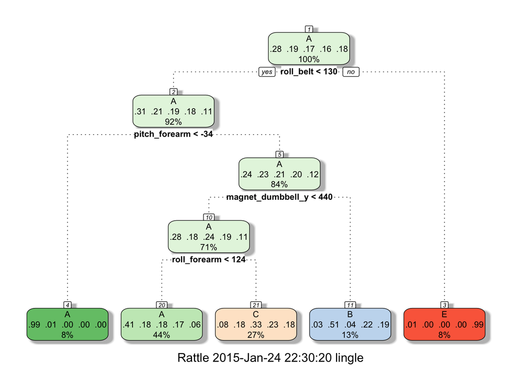

```r
#
fit <- train(classe~.,method="rpart",data=pmlTrainSmall)
## Loading required package: rpart
fit$finalModel
## n= 19622
##
## node), split, n, loss, yval, (yprob)
##       * denotes terminal node
##
##  1) root 19622 14042 A (0.28 0.19 0.17 0.16 0.18)
##    2) roll_belt< 130.5 17977 12411 A (0.31 0.21 0.19 0.18 0.11)
##      4) pitch_forearm< -33.95 1578    10 A (0.99 0.0063 0 0 0) *
##      5) pitch_forearm>=-33.95 16399 12401 A (0.24 0.23 0.21 0.2 0.12)
##       10) magnet_dumbbell_y< 439.5 13870  9953 A (0.28 0.18 0.24 0.19 0.11)
##         20) roll_forearm< 123.5 8643  5131 A (0.41 0.18 0.18 0.17 0.061) *
##         21) roll_forearm>=123.5 5227  3500 C (0.077 0.18 0.33 0.23 0.18) *
##       11) magnet_dumbbell_y>=439.5 2529  1243 B (0.032 0.51 0.043 0.22 0.19) *
##    3) roll_belt>=130.5 1645    14 E (0.0085 0 0 0 0.99) *
# plot the final model
fancyRpartPlot(fit$finalModel)
```

```r
# What is the in sample error
trainfit <- predict(fit,pmlTrain)
trainfittbl <- table(trainfit,pmlTrain$classe)
numright <- trainfittbl[1,1]+trainfittbl[2,2]+trainfittbl[3,3]+trainfittbl[4,4]+trainfittbl[5,5]
numright
## [1] 9724
# calculate the percentage accurate on the training set
numright/dim(pmlTrain)[1]
## [1] 0.4955662
# predict on the test set
testfit <- predict(fit,pmlTest)
testfit
##  [1] C A C A A C C A A A C C C A C A A A A C
## Levels: A B C D E
```

```r
cm <- confusionMatrix(trainfit,pmlTrain$classe)
cm
```

```
## Confusion Matrix and Statistics
##
##           Reference
## Prediction    A    B    C    D    E
##          A 5080 1581 1587 1449  524
##          B   81 1286  108  568  486
##          C  405  930 1727 1199  966
##          D    0    0    0    0    0
##          E   14    0    0    0 1631
##
## Overall Statistics
##
##                Accuracy : 0.4956
##                  95% CI : (0.4885, 0.5026)
##     No Information Rate : 0.2844
##     P-Value [Acc > NIR] : < 2.2e-16
##
##                   Kappa : 0.3407
##  Mcnemar's Test P-Value : NA
##
## Statistics by Class:
##
##                      Class: A Class: B Class: C Class: D Class: E
## Sensitivity            0.9104  0.33869  0.50468   0.0000  0.45218
## Specificity            0.6339  0.92145  0.78395   1.0000  0.99913
## Pos Pred Value         0.4970  0.50850  0.33040      NaN  0.99149
## Neg Pred Value         0.9468  0.85310  0.88225   0.8361  0.89008
## Prevalence             0.2844  0.19351  0.17440   0.1639  0.18382
## Detection Rate         0.2589  0.06554  0.08801   0.0000  0.08312
## Detection Prevalence   0.5209  0.12889  0.26638   0.0000  0.08383
## Balanced Accuracy      0.7721  0.63007  0.64431   0.5000  0.72565
```

### A Random Forest Model

In order to improve accuracy we construct a model using random forests. Again we use all 52 predictors to compute the model. The in sample error rate for this model is 0%. This is of some concern as we may hove overfit the data; however, when we classified the test data all answers were accepted as correct.

```r
# takes a very long time
rffit <- train(classe~.,method="rf",data=pmlTrainSmall)
rfpred <- predict(rffit,pmlTrain)
rftbl <- table(rfpred,pmlTrain$classe)
rftbl
```

```
##
## rfpred    A    B    C    D    E
##      A 5580    0    0    0    0
##      B    0 3797    0    0    0
##      C    0    0 3422    0    0
##      D    0    0    0 3216    0
##      E    0    0    0    0 3607
```

```r
rftestpred <- predict(rffit,pmlTest)
rftestpred
```

```
##  [1] B A B A A E D B A A B C B A E E A B B B
## Levels: A B C D E
```

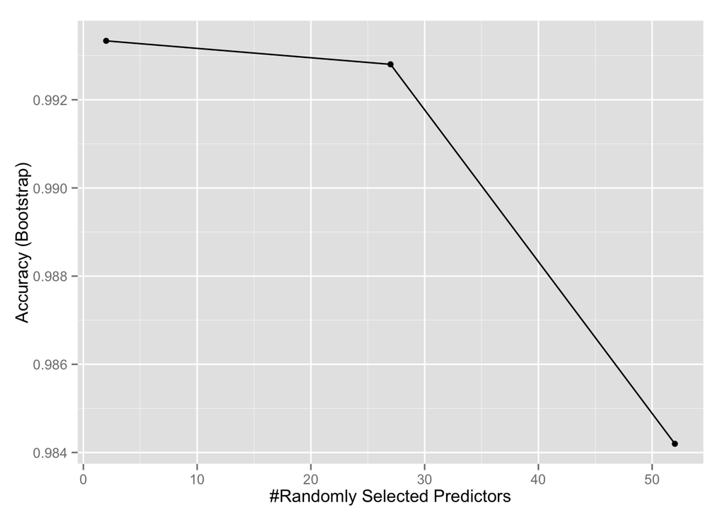

```r
ggplot(rffit, metric="Accuracy")
```

```r
varImp(rffit)
```

```
## rf variable importance
##
##   only 20 most important variables shown (out of 52)
##
##                      Overall
## roll_belt             100.00
## yaw_belt               78.64
## magnet_dumbbell_z      71.84
## pitch_belt             68.01
## magnet_dumbbell_y      66.14
## pitch_forearm          59.43
## magnet_dumbbell_x      54.68
## roll_forearm           53.05
## accel_dumbbell_y       46.15
## magnet_belt_z          44.75
## accel_belt_z           44.53
## roll_dumbbell          42.37
## accel_dumbbell_z       38.66
## magnet_belt_y          38.23
## roll_arm               35.76
## accel_forearm_x        34.45
## gyros_belt_z           32.38
## yaw_dumbbell           30.47
## total_accel_dumbbell   27.97
## magnet_forearm_z       27.86
```

```r
rffitSmall <- train(classe~roll_belt+yaw_belt+magnet_dumbbell_z+magnet_dumbbell_y+pitch_belt+pitch_forearm+magnet_dumbbell_x+roll_forearm,method="rf",data=pmlTrainSmall)
rfSmallPred <- predict(rffitSmall,pmlTrain)
table(rfSmallPred,pmlTrain$classe)
```

```
##
## rfSmallPred    A    B    C    D    E
##           A 5580    0    0    0    0
##           B    0 3797    1    0    0
##           C    0    0 3421    0    0
##           D    0    0    0 3216    0
##           E    0    0    0    0 3607
```

```r
rfSmallPredTest <- predict(rffitSmall,pmlTest)
rfSmallPredTest
```

```
##  [1] B A B A A E D B A A B C B A E E A B B B
## Levels: A B C D E
```

```r
varImp(rffitSmall)
```

```
## rf variable importance
##
##                   Overall
## roll_belt         100.000
## yaw_belt           64.032
## pitch_belt         40.388
## pitch_forearm      26.342
## magnet_dumbbell_z  18.400
## magnet_dumbbell_y  14.198
## roll_forearm        8.718
## magnet_dumbbell_x   0.000
```